# PM2.5 Forecasting

# The second model has better performance to fit the data

# Assessing test set performance

```r
pred1 <- predict(pm2.5.lm1.ihs, test)
pred2 <- predict(pm2.5.lm2.step, test)
head(pred1)
```

```
##    29681     6080     6639    22972     4895    33369
## 4.794975 4.669995 4.573542 5.889805 5.141580 4.895222
```

```r
head(pred2)
```

```
##    29681     6080     6639    22972     4895    33369
## 4.652420 4.703010 4.817894 5.612322 5.139300 5.175095
```

Plotting of train and test data against actural performance

```r
train.pred1 <- predict(pm2.5.lm1.ihs)
test.pred1 <- predict(pm2.5.lm1.ihs, test)
train.pred2 <- predict(pm2.5.lm2.ihs)
test.pred2 <- predict(pm2.5.lm2.ihs, test)
```

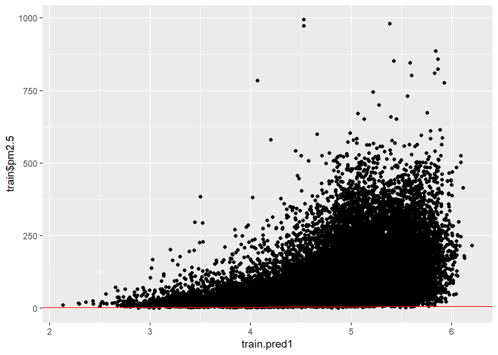

```r
plot.train1 <- ggplot(train, aes(x = train.pred1, y = train$pm2.5)) +
  geom_point() +
  geom_abline(color = "red")

plot.test1 <- ggplot(test, aes(x = test.pred1, y = test$pm2.5)) +
  geom_point() +
  geom_abline(color = "red")

plot.train1
```

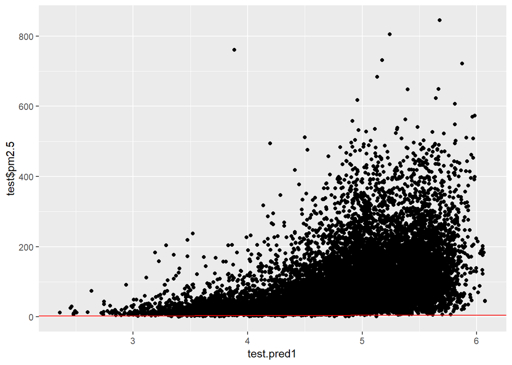

```r
plot.test1
```

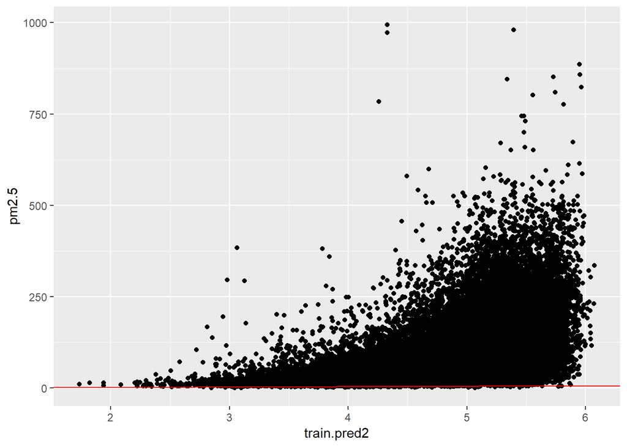

```r
plot.train2 <- ggplot(train, aes(x = train.pred2, y = pm2.5)) +
  geom_point() +
  geom_abline(color = "red")

plot.test2 <- ggplot(test, aes(x = test.pred2, y = pm2.5)) +
  geom_point() +
  geom_abline(color = "red")

plot.train2
```

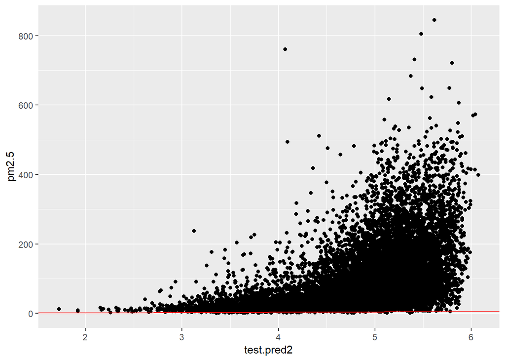

```r
plot.test2
```

# Check which model is fitting better

# Test for pm2.5.lm1.ihs

```r
predictions <- pm2.5.lm1.ihs%>% predict(test)
data.frame( R2 = R2(predictions, test$pm2.5),
            RMSE = RMSE(predictions, test$pm2.5),
            MAE = MAE(predictions, test$pm2.5))
```

```
##          R2     RMSE    MAE
## 1 0.2326135 130.9954 93.623
```

# Test for the pm.2.5.lm2.step

```r
predictions <- pm2.5.lm2.step%>% predict(test)
data.frame( R2 = R2(predictions, test$pm2.5),
            RMSE = RMSE(predictions, test$pm2.5),
            MAE = MAE(predictions, test$pm2.5))
```

```
##         R2     RMSE      MAE
## 1 0.260747 130.9712 93.62059
```

# Now we and see that the second model is more optimal model, but from the plot above, both models doesn’t have good performance. And to improve the performance, we need to check if the model has multicollinearity problem.

# VIF and Conditional Number k

```r
vif(pm2.5.lm2.step)
```

```
##         DEWP         TEMP         PRES           SW           NE
## 39314.494844 35236.358062     9.781866     5.094843 37398.601676
##           NW    DEWP:PRES      DEWP:SW      DEWP:NE      DEWP:NW
## 37094.554141 39556.296408     6.031905     5.581207     6.861035
##    TEMP:PRES      TEMP:SW      TEMP:NE      TEMP:NW      PRES:NE
## 34893.435631    10.650441     9.714858     9.452146 37046.697804
##      PRES:NW
## 36885.430947
```

```r
kappa(pm2.5.lm2.step)
```

```
## [1] 16862891
```

# VIF is almost bigger than 5 or 10 and Condtional Number is bigger than 30, which implys that there exits severe multicollinearity problem

# LASSO

```r
x = model.matrix(pm2.5.lm2.step)
y = train$pm2.5
```

# Setting Parameters

```r
set.seed(888)
train1 = sample(1:nrow(train), .7 * nrow(train))
test1 = (-train1)
ytest = y[test1]
lambda <- 10^seq(10, -2, length = 100)
```

# Choosing Best lambda

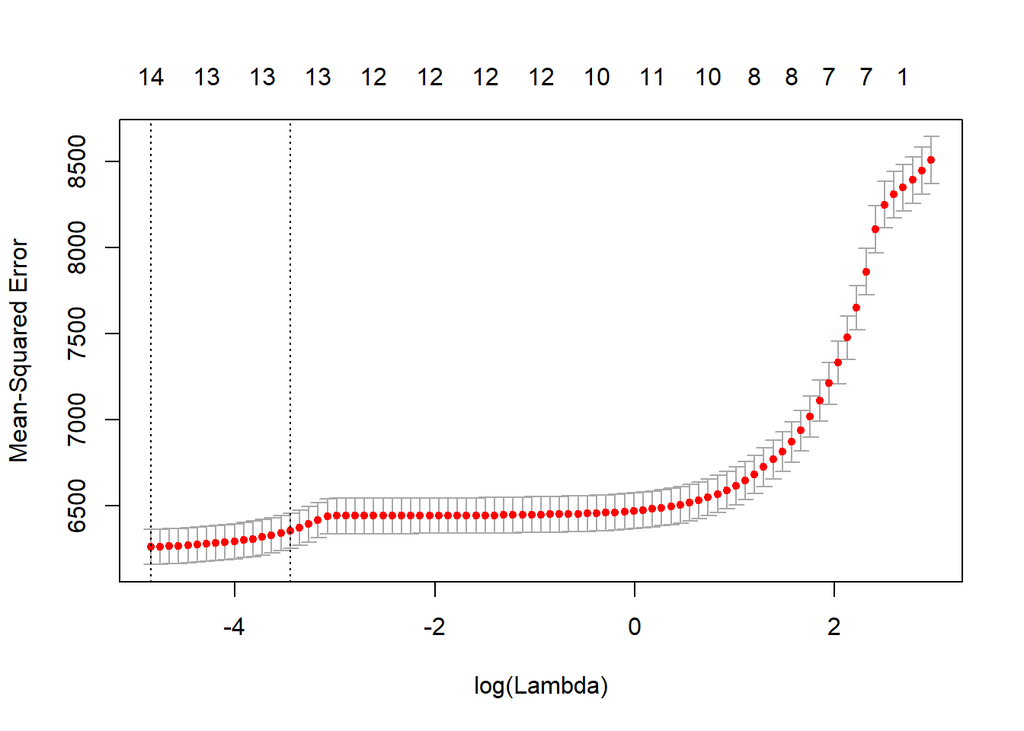

```r
cv.out <- cv.glmnet(x[train1, ], y[train1], alpha = 1)
plot(cv.out)
```

```r
bestlam <- cv.out$lambda.min
```

# The Plot of Lambda

# Lasso Predictions

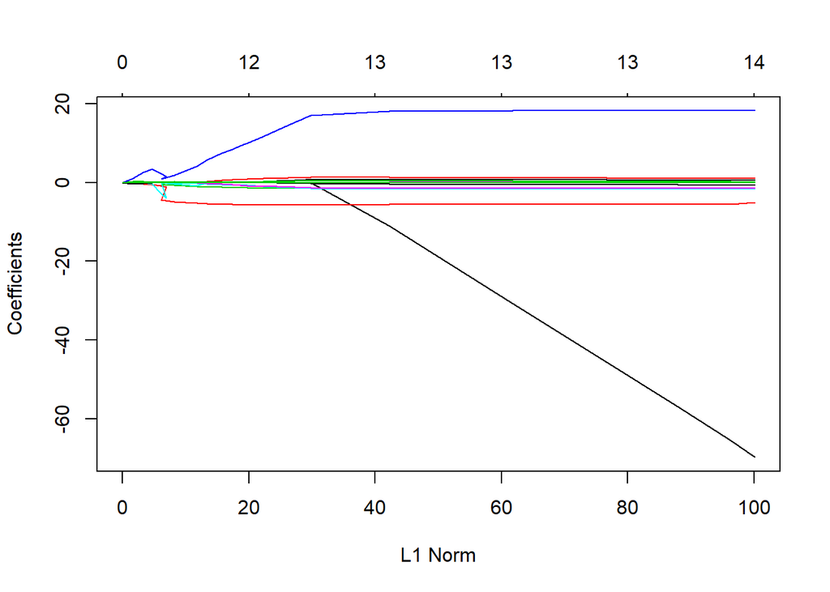

```r
lasso.mod <- glmnet(x[train1, ], y[train1], alpha = 1, lambda = lambda)
plot(lasso.mod)
```

```r
lasso.pred <-predict(lasso.mod, s = bestlam, newx = x[test1,])
mean((lasso.pred - ytest)^2)
```

```
## [1] 6237.932
```